# Primer Trabajo Grupal EDAED

Deyner Lopez Pineda, Maria Alejandra Otalvaro Quintero, Stephanie Daysi Tamayo Picuasi, Hadeil Bittencourt

28/9/2020

Introducción

En el curso de Estadística Descriptiva y Análisis Exploratorio de Datos (EDAED) se realizó una encuesta en la cual se preguntó sobre el género, el P.A.P.A, algunas preguntas referentes a la pandemia, hábitos de estudio y también elegir un número aleatorio del 1 al 10. En el curso de EDAED están inscritas 158 personas, sin embargo, la encuesta la contestaron 132, con base en eso trabajaremos los datos con los 132 encuestados de 158. En el trabajo desarrollaremos tablas y gráficos para poder comprobar con datos reales las conclusiones a las que lleguemos.

Analisis de la variable Genero

La variable género en la encuesta se divide en tres clasificaciones, femenino, masculino y otro. Como se mencionó anteriormente se trabajarán con 132 datos. Con eso en mente sale la siguiente tabla de frecuencia:

| Genero | Cantidad de Respuestas |
| --- | --- |
| Femenino | 35 |
| Masculino | 97 |

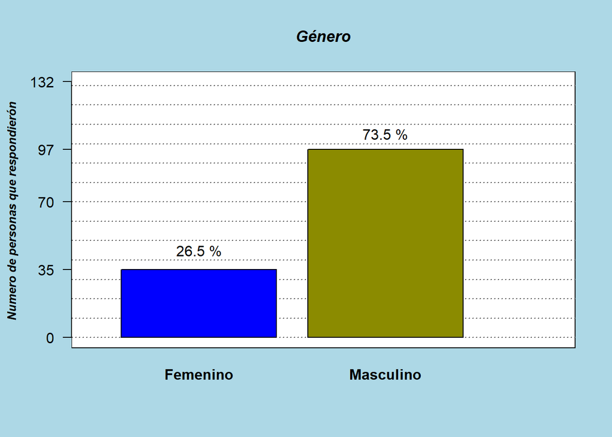

En la gráfica se observa:

- El 26.5% son de sexo femenino y el 73.5% son de sexo masculino, por lo tanto, se llega a la conclusión que en el curso de EDAED están inscritos más hombres que mujeres.
- Se observa que en el curso EDAED ninguno de los encuestados selecciono la clasificación de otros. Con los datos obtenidos en la pregunta se resume que en el curso no hay personas con otro género, es decir personas que no encajan ni en el género masculino ni en el femenino, la mayoría son hombres y hay pocas mujeres.

Analisis de la variable Fecha de nacimiento (Edad)

En la variable fecha de nacimiento no se tomarán en cuenta las fechas que tengan como año 2020 para el análisis del rango de años del curso de EDAED, dado que generaría datos atípicos ya que es imposible que una persona nacida en el 2020 este inscrita en el curso. Para las personas que escribieron de manera errónea se corrigieron (los que pusieron guion en lugar de barra inclinada, confundieron el orden), a los que solo escribieron el año se pondrá el mes y día de la mitad del año, generando así un promedio. De igual manera a los que pusieron el año actual se realizara un promedio de los años que se obtuvieron de respuesta, de ese modo se sustituirá aquellos que tengan el año actual con el promedio obtenido. Con la depuración anterior se utilizará para sacar las edades que pueden tener los encuestados en el curso de EDAED, el proceso de sustituir a aquellos que escribieron el año actual con el promedio obtenido es para lograr sacar sus edades de manera aproximada y obtener la siguiente tabla:

| Edad | Número de Respuestas |
| --- | --- |
| 15 | 1 |
| 16 | 2 |
| 17 | 11 |
| 18 | 16 |
| 19 | 24 |
| 20 | 22 |
| 21 | 12 |
| 22 | 7 |
| 23 | 6 |
| 24 | 7 |
| 25 | 3 |
| 26 | 3 |
| 27 | 3 |
| 28 | 1 |
| 31 | 1 |
| 33 | 1 |
| 37 | 1 |
| 38 | 1 |
| 43 | 1 |
| 63 | 1 |

Con la información anterior se obtiene la siguiente gráfica:

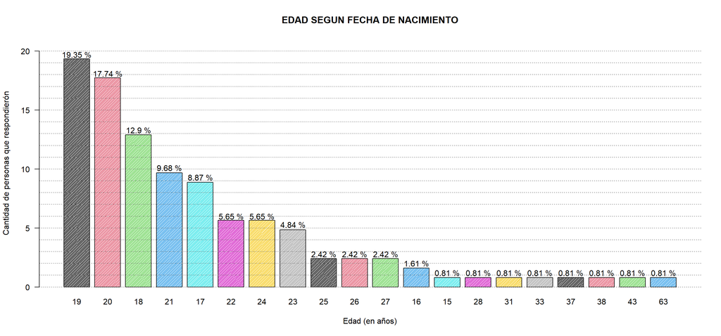

En la gráfica se observa:

- Las edades más frecuentes están en los 18,19 y 20 años, lo que al sumar sus porcentajes obtenemos como resultado un 49.99% que es aproximadamente la mitad de los encuestados.
- Las edades menos frecuentes se encuentran en los 15,28,31,33,37,38,43 y 63, al sumar sus porcentajes obtenemos que conforman el 6.48% que es aproximadamente un poco más de un dieciseisavo de los encuestados.
- Las edades de 16,17,21,22,23,24,25,26 y 27 conforman el 43. 56% al sumar sus porcentajes.

Con las observaciones anteriores y el total de los encuestados se puede decir que en el curso de EDAED hay más estudiantes con edades entre los 18,19 y 20 años.

Analisis de la variable Carrera

En la variable carrera se juntarán aquellas asignaturas que sean iguales, porque cada encuestado tiene una manera diferente de referirse a una misma cosa u objeto. De esa manera obtenemos que aquellos que escribieron todo en mayúscula o sin tilde y con tilde para una misma carrera se juntaran escribiéndola de manera correcta, además también están aquellos que solo escribieron las siglas o la mitad del nombre de la carrera, esos datos también se unificaron y se redujeron a una sola que tenga el mismo significado para todas las que están escritas de esa manera. Con lo anterior obtenemos la siguiente tabla:

| Carrera | Cantidad de Respuestas |
| --- | --- |
| Estadistica | 70 |
| Ingenieria administrativa | 3 |
| Ingenieria biologica | 1 |
| Ingenieria de control | 1 |
| Ingenieria de sistemas | 50 |
| Ingenieria Fisica | 3 |
| Ingenieria industrial | 2 |
| Matematica | 2 |

Con la información anterior se obtiene la siguiente gráfica:

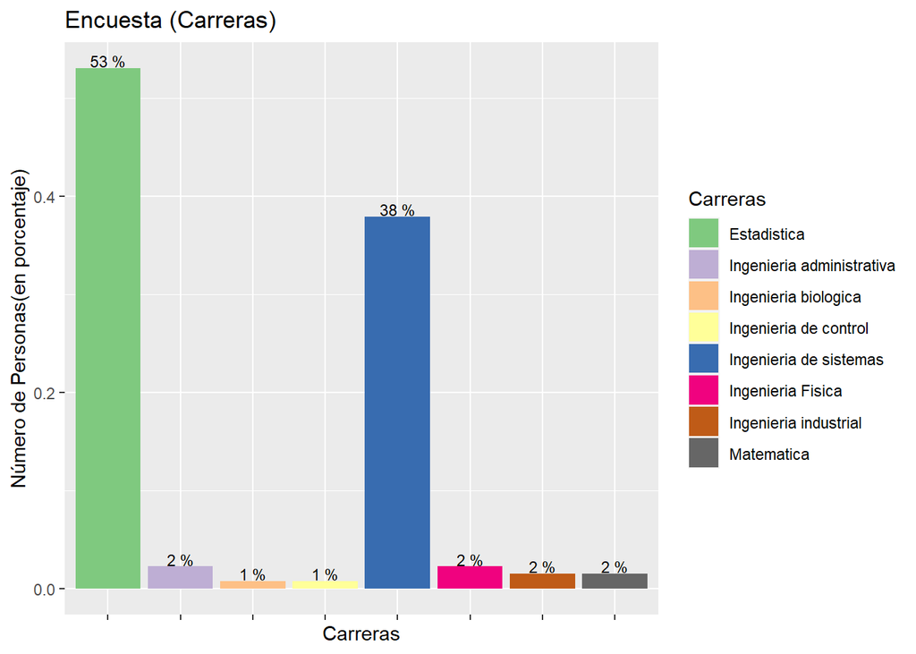

En la gráfica se observa:

- El 53% de los estudiantes encuestados pertenecen a la carrera de estadística.
- El 38% de los estudiantes son de la carrera de ingeniería en sistemas.
- El 10% de los estudiantes están divididos de la siguiente manera: 2% ingeniería administrativa, 2% ingeniería física, 2% matemáticas, 2% ingeniería industrial, 1% ingeniería biológica y 1% ingeniería de control.

Con los resultados anteriores notamos que la mayoría del curso están en las carreras de estadística e ingeniería en sistemas, son pocas las personas pertenecientes a otras carreras. Mirando la información y bases obtenidas en curso consideraría que seria propicio que más personas de diferentes carreras tengan la oportunidad de tomar el curso.

Analisis de la variable PAPA

El Promedio Académico Ponderado Acumulado (PAPA) tiene un intervalo de calificación del 0 al 5, aunque el intervalo sea de 0 a 5 no es usual que estén estudiantes con un PAPA menor a 2.7 por lo que si sacan menos de 2.7 estarían por fuera de la universidad, también se diría que aquellos que tengan un PAPA menor al de 3.0 ya están por fuera, sin embargo la universidad tiene un formato de reingreso para aquellos estudiantes que tengan el PAPA entre 2.7 y 2.9, de modo que no sería raro entrar algún estudiante sea de reingreso.  
En la encuesta responder a esta pregunta era opcional, de modo que obtuvimos personas que no respondieron. Por tal motivo se procedió a hacer un promedio de las notas, con el resultado obtenido se llenaron las respuestas de aquellas estudiantes que no respondieron a la encuesta. Teniendo en cuenta los criterios anteriores se obtuvo la siguiente tabla de frecuencia del PAPA:

| PAPA | Frecuencia |
| --- | --- |
| 3 | 9 |
| 3.1 | 1 |
| 3.2 | 1 |
| 3.3 | 5 |
| 3.4 | 8 |
| 3.5 | 17 |
| 3.6 | 17 |
| 3.7 | 7 |
| 3.8 | 20 |
| 3.85 | 1 |
| 3.9 | 8 |
| 4 | 12 |
| 4.1 | 4 |
| 4.2 | 3 |
| 4.3 | 5 |
| 4.5 | 1 |
| 4.6 | 2 |
| 4.7 | 2 |

Con la tabla de frecuencia sacamos los siguientes datos:

```
##    Min. 1st Qu.  Median    Mean 3rd Qu.    Max.
##   3.000   3.500   3.700   3.709   3.900   4.700
```

Con los datos anteriores se observa:

- El menor resultado obtenido es de 3.0 y el mayor es de 4.7.
- Obtenemos la media y la mediana con valores similares, lo cual indica que para este caso en la pregunta no se obtuvieron datos atípicos que pudieran sesgar la información obtenida.
- El 25% de las calificaciones del PAPA son menores o iguales a 3.5 y el 75% de las calificaciones del PAPA son menores o iguales a 3.9.

Teniendo en cuenta los datos anteriores se procede a hacer un histograma con la variable PAPA:

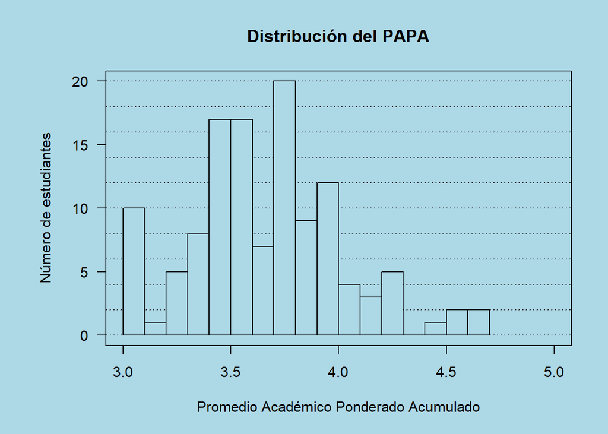

Analisis de la variable Estrato

En la variable estrato se tiene en cuenta que en Colombia el estrato se divide del uno (1) al seis (6). En la encuesta no era obligatorio responder a la pregunta, sin embargo, de todos los encuestados solo una persona no respondió. En este caso para la depuración de ese dato se sacó el promedio de todas las respuestas y se relleno el N/A con el resultado del promedio. Obteniendo de esa manera la siguiente tabla de frecuencia:

| Estrato | Respuestas |
| --- | --- |
| 0 | 1 |
| 1 | 17 |
| 2 | 45 |
| 3 | 59 |
| 4 | 9 |
| 5 | 1 |

Con la tabla de frecuencia sacamos los siguientes datos:

```
##    Min. 1st Qu.  Median    Mean 3rd Qu.    Max.
##   0.000   2.000   3.000   2.462   3.000   5.000
```

Con los datos anteriores se observa:

- El menor resultado obtenido es de 0 y el mayor es de 5
- Obtenemos la media y la mediana con valores similares, lo cual indica que para este caso en la pregunta no se obtuvieron datos atípicos que pudieran sesgar la información obtenida.
- El 25% de los estudiantes del curso de EDAED son de estrato menores o iguales a 2 y el 75% son menores o iguales a 3.

Con la información anterior se obtiene el siguiente histograma:

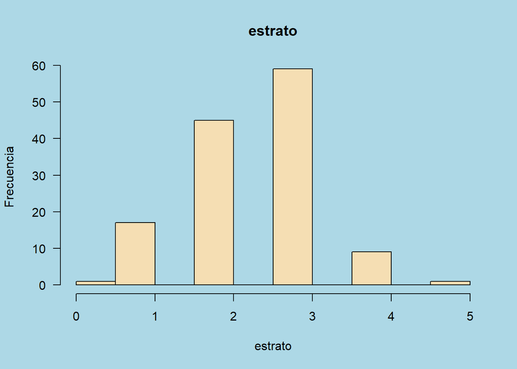

En la gráfica observamos:

Con los resultados podemos ver que a pesar de que la clasificación de los estratos es de 0 a 6, no se obtuvieron estudiantes que pertenezcan al estrato 6, también que la mayoría de los estudiantes pertenecen al estrato 0,1, 2 y3 lo que indica que la mayoría no tiene los recursos necesarios y algunos obtienen beneficios de subsidios.

Analisis de la variable Computador

La pregunta de la encuesta es una con cuatro opciones de respuesta, lo cual convierte esas cuatro opciones en nuestras cuatro clasificaciones para esta variable.

Con los datos obtenidos se realiza una tabla de frecuencia:

| Repuesta | Cantidad de Respuestas |
| --- | --- |
| No | 91 |
| Si, pero prestado | 3 |
| Si, pero alquilado. | 1 |
| Si, propio. | 37 |

Con la información anterior se obtiene la siguiente gráfica:

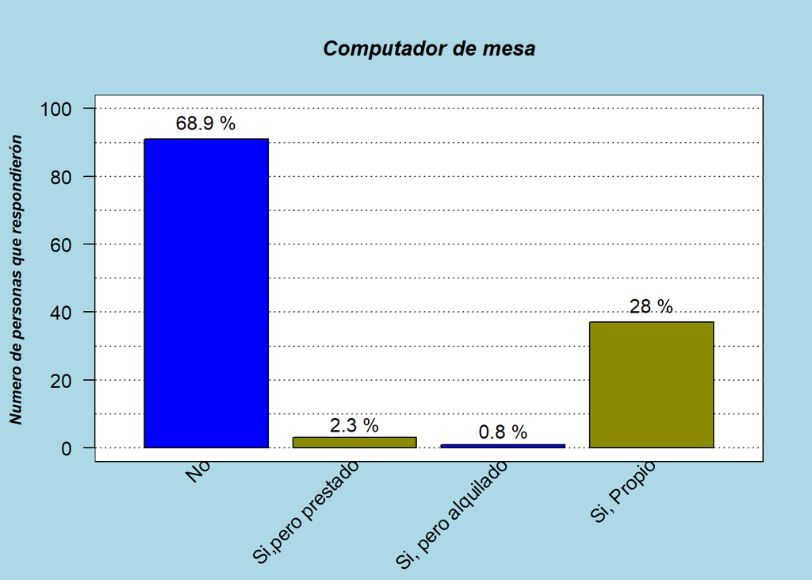

En la gráfica se observa:

- El 68.9% de las personas no poseen un computador de mesa.
- El 28% de los encuestados poseen un computador de mesa propio.
- Los porcentajes más bajos están en dos opciones de respuesta el 2.3% es de las personas que tienen el computador de mesa, pero es prestado y el 0.8% es de las personas que tienen alquilado el computador de mesa.

Con las respuestas obtenidas en esta pregunta nos informamos de la situación por la cual pasan los estudiantes, con esto sabemos que la mayoría no posee un computador de mesa en sus hogares que supera por mucho a aquellos que si poseen un computador de mesa propio.

Analisis de la variable Portatil

En la pregunta de si tiene computador portátil disponible se tiene cuatro opciones de pregunta que se convertirán en las clasificaciones. Obteniendo así la siguiente tabla de frecuencia:

| Respuesta | Cantidad de respuestas |
| --- | --- |
| No | 18 |
| Si, pero alquilado. | 1 |
| Si, pero prestado. | 16 |
| Si, propio. | 97 |

Con la información se realiza la siguiente gráfica:

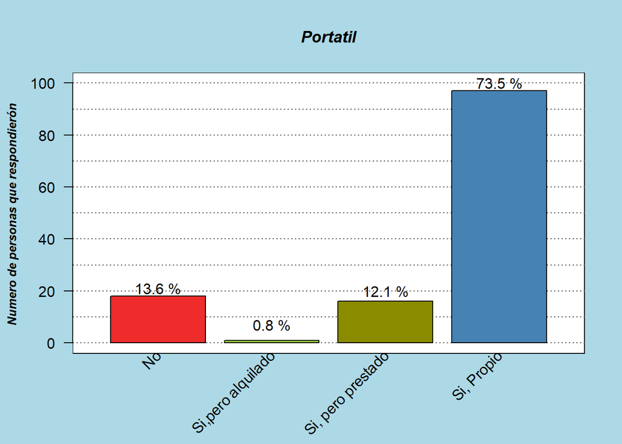

En la gráfica se observa:

- El 73.5% poseen portátil propio, que es un porcentaje muy alto comparado con los otros porcentajes de las otras opciones.
- El 13.6% no posee portátil, el 0.8% tiene un portátil, pero es alquilado y el 12.1% tiene un portátil, pero es prestado.

Al sumar los porcentajes se obtiene un 26.5% que es una cuarta parte de los encuestados. Con los resultados observamos que más de la mitad posee un computador propio, lo cual seria de esperarse de esperarse, suponiendo que llegados a esta materia se debería contar con un portátil, ya que esa es una herramienta para nuestro trabajo. Aun así, uno creería que lo ideal fuera que todos tuvieran uno ya que nos encontramos en el siglo XXI, donde se supone es la era de la tecnología y más en tiempos como los de la situación actual que nos obliga a actualizar y realizar casi todo de forma virtual.

Analisis de la variable Internet

En la pregunta de si se tiene internet disponible se tenían siete opciones de respuestas las cuales se convertirán en las clasificaciones. Teniendo en cuenta que se tienen siete opciones de respuesta se sacan las frecuencias de cada una, dando como resultado la siguiente tabla:

| Respuestas | Cantidad de respuestas |
| --- | --- |
| Si, alquilado. | 6 |
| Si, de “contrabando” | 1 |
| Si, pero plan de datos de celular. | 4 |
| Si, prestado. | 5 |
| Si, propio. | 44 |
| Si. familiar, | 72 |

Con la información anterior se realiza una gráfica:

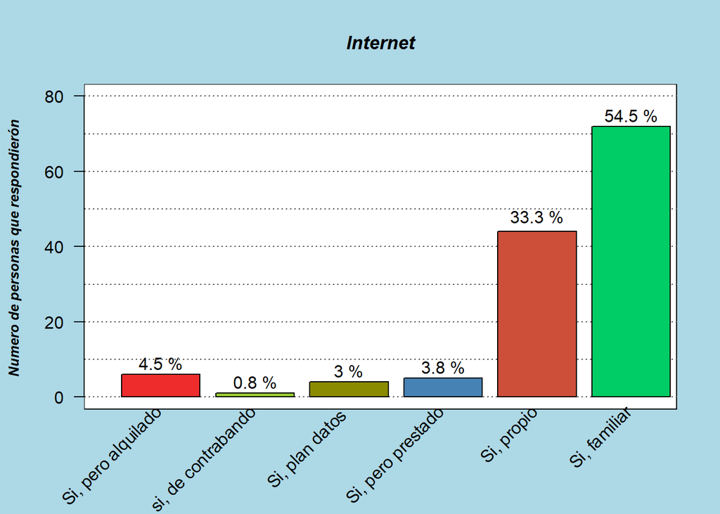

En la gráfica se observa:

- El 54.5% tiene internet familiar y el 33.3% tiene internet propio, los cuales son los porcentajes más altos, al sumar los porcentajes obtenemos un 87.8%.
- Los que tienen porcentajes más bajos de la forma en la que tienen el internet son 4.5% alquilado, 0.8% de contrabando, 3% plan de datos y 3.8% prestado, al sumar los porcentajes da un total del 12.1%.

Con los resultados observamos todos poseen un internet de diferentes formas, claro que se puede decir que las mejores opciones son las que tienen un mayor porcentaje en esta encuesta, sin embargo, nos encontramos que hay personas de que a pesar de tener internet lo tienen de una manera que no es tan legal y de otra que limita mucho el acceso. Lo que nos podría dar una buena señal es que a pesar de todos los inconvenientes ninguno de los encuestados no tiene internet, dada la situación actual es bueno porque dependemos totalmente del internet para diferentes actividades.

Analisis de la variable SmartPhone

En la pregunta de si poseían celular inteligente se tiene cuatro opciones de respuesta, sin embargo, al no ser una pregunta de carácter obligatorio se puede decir que tiene la opción de no respuesta, de manera que no serían cuatro opciones sino cinco. Con eso en mente se obtiene a siguiente tabla de frecuencias:

| Repsuesta | cantidad de respuestas |
| --- | --- |
| No | 1 |
| No Respondio | 1 |
| Si, alquilado. | 1 |
| Si, prestado. | 2 |
| Si, propio. | 127 |

Con la información anterior se obtiene la siguiente gráfica:

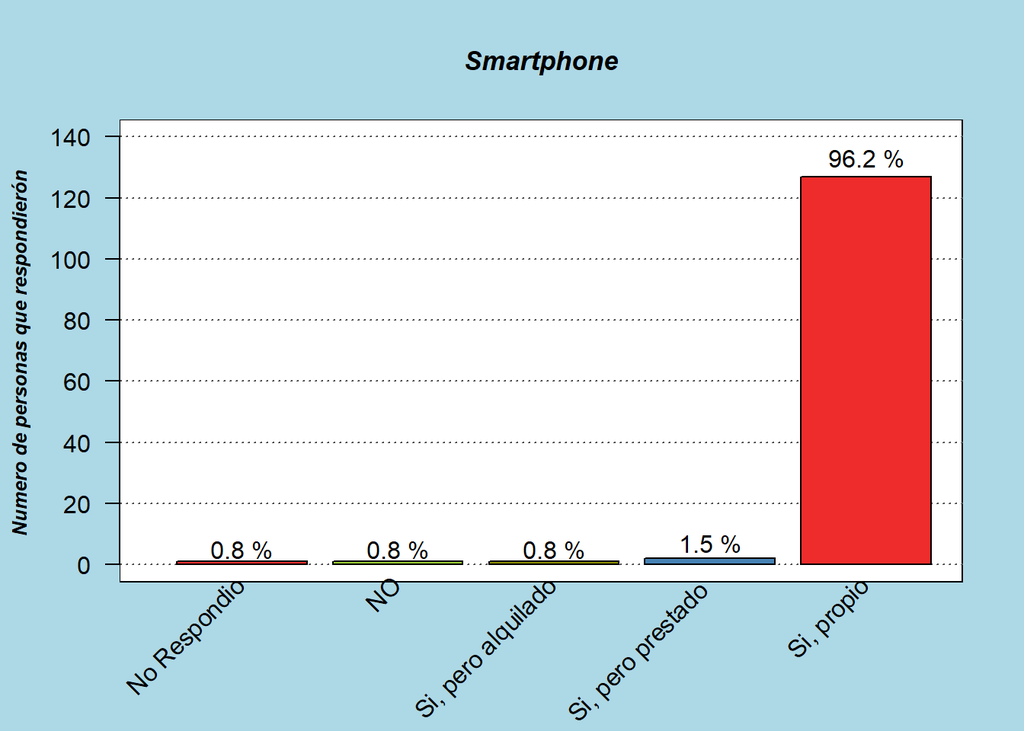

En la gráfica se observa:

- El 96.2% poseen celular propio, el 0.8% tiene, pero es alquilado y el 1.5% tiene, pero es prestado, si sumamos el porcentaje de los que si tienen celular de una u otra forma obtenemos un 98.5% que es casi la totalidad del número de encuestados.
- El 0.8% no tiene celular.
- El 0.8% no respondió.

Con los resultados obtenidos podemos decir que a pesar de no tener un portátil o computador de mesa (datos analizados anteriormente), casi la totalidad del curso posee un celular. Lo que hasta cierto punto es positivo porque se puede tener la tranquilidad de que se puede tener contacto con las personas y los trabajos.

Analisis de la variable Origen covid- 19

Para la pregunta de como consideraban el origen del covid-19 se tenia cuatro opciones de respuesta, sin embargo, se podría decir que aunque no es explícitamente escrito el hecho de no responder es otra opción, ya que la pregunta no era obligatoria, también se diría que aquella persona que no respondió la encuesta tendría dos posibles razones no estaba de acuerdo con las opciones o no quería dar su postura frente a la pregunta. Con las explicaciones anteriores se obtiene la siguiente tabla de frecuencia:

| Origen | Respuestas |
| --- | --- |
| Fue un resultado de pasar el virus de animales a los humanos | 74 |
| Fue fabricado en un laboratorio | 47 |
| No Respondieron | 15 |
| es una conspiracin | 8 |
| No es real, es un pretexto de los gobiernos del mundo | 3 |

Con la información anterior se obtiene la siguiente gráfica:

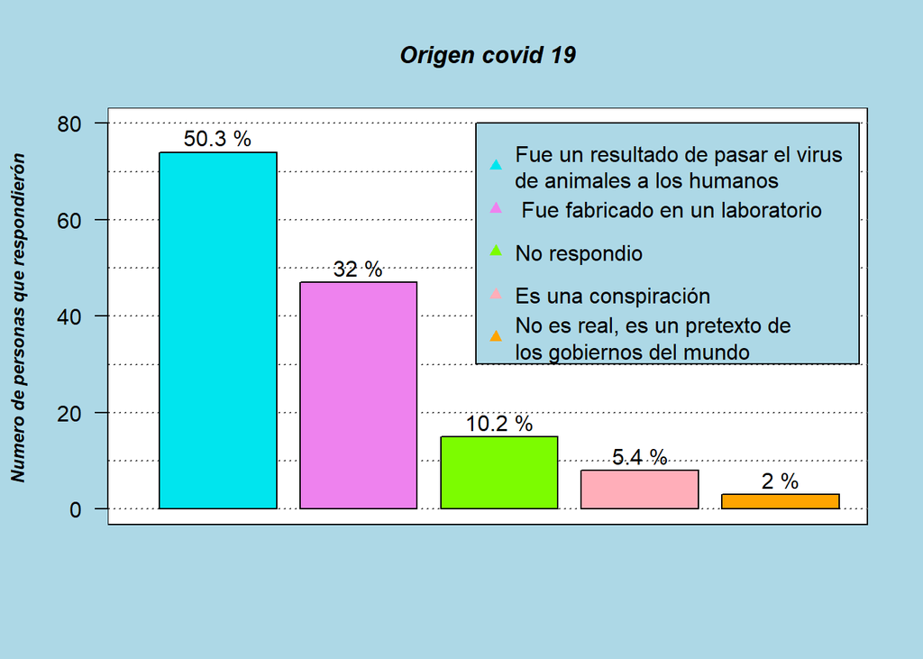

En la gráfica se observa:

- El 50.3% considera que el origen de la pandemia del covid-19 fue resultado de pasar el virus de animales a los humanos.
- El 32% considera que el origen de la pandemia del covid-19 fue fabricado en un laboratorio.
- El 5.4% considera que el origen de la pandemia del covid-19 se trata de una conspiración.
- El 2% considera que el origen de la pandemia del covid-19 no es real, es un pretexto de los gobiernos del mundo.
- El 10.2% no respondió a la pregunta sobre cual considera que es el origen del covid-19.

Considerando los resultados obtenemos criterios diferentes sobre las posturas que cada persona tiene sobre el origen del covid-19, sin embargo, notamos que la mitad del curso coincide en una de las opciones, y que fueron pocas las personas que por diferentes motivos no quisieron definir cuál era la opción que creían.

Analisis de la variable Estado Gov

Para la pregunta de si cree en los datos y estadísticas que emite el gobierno sobre el desarrollo de la pandemia en Colombia como opciones de respuesta se tenían dos, sin embargo, como lo mencionamos con anterioridad al no ser obligatoria se toma la posibilidad de que algunos no respondan por razones diferentes. Con las observaciones anteriores se obtiene la siguiente tabla de frecuencia:

| Respuesta | Número de Respuestas |
| --- | --- |
| No | 88 |
| No Respondieron | 14 |
| Si | 30 |

Con la información anterior se obtiene la siguiente gráfica:

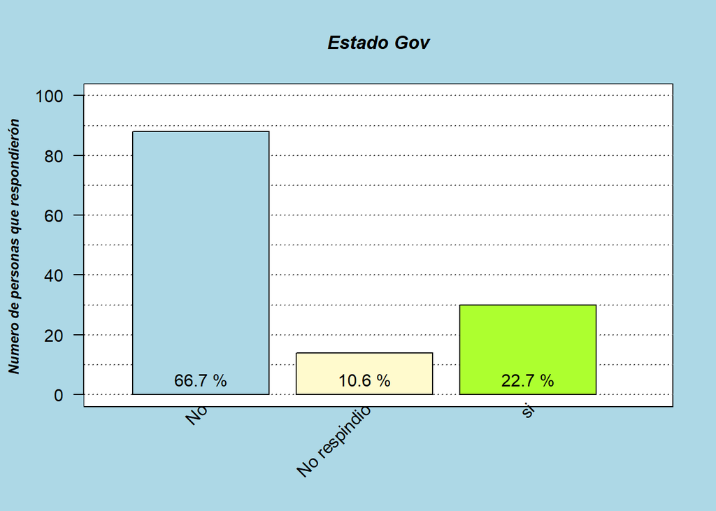

En la gráfica se observa:

- El 66.7% de las personas respondió que no cree en los datos estadísticos del gobierno.
- El 22.7% de los encuestado respondió que si creen en los datos estadísticos del gobierno.
- El 10.6% de las personas no respondió si creían o no en los datos estadísticos del gobierno.

Con los resultados obtenidos tenemos que más de la mitad no cree en los datos estadísticos del gobierno, aunque es verdad que hay que cuestionarse de donde y como sacan los datos y los resultados tampoco quiere decir que no se debe creer en algunas de las informaciones que transmite el gobierno. Lo mismo se podría decir de las personas que respondieron que si creían, aunque es verdad que se debería creer en los datos emitidos por el gobierno, también es cierto que en algunas ocasiones se tienen anomalías, de manera que en algunas veces se podrían cuestionar sobre los datos. Y para los que no respondieron seria bueno si pudieran tener una clara postura de lo que creen que es verdadero o falso.

Analisis de la variable Habitos

Esta pregunta sobre cuales son los hábitos de estudio de los estudiantes tenía una selección múltiple, es decir, se podían seleccionar varias opciones. Esta pregunta tenía 21 opciones diferentes. Con la cual se obtiene la siguiente tabla de frecuencia:

| Habito | Número de respuestas |
| --- | --- |
| Estudia solamente las soluciones de los libros o de los compañeros. | 3 |
| Estudia con amigos. | 15 |
| Memoriza ejercicios. | 19 |
| Los ejercicios los hace junto con los amigos de estudio. | 27 |
| Prefiere dar un vistazo a ejercicios resueltos de todos los posibles ejercicios. | 35 |
| Estudia todo el tema el día anterior del examen. | 36 |
| Estudia varios temas distintos en una misma sesión de estudio. | 36 |
| Hace un horario de estudio y se ajusta estrictamente a ese horario. | 44 |
| Madruga a estudiar. | 45 |
| Escucha su música favorita mientras estudia. | 49 |
| Lee varias veces un mismo capítulo del libro texto. | 50 |
| Trasnocha estudiando para un examen. | 52 |
| Estudia solo. | 59 |
| Solo le pregunta a los amigos los ejercicios que no pudo resolver. | 62 |
| Prefiere pocos ejercicios bien entendios a dar un vistazo a muchos ejercicios resueltos. | 68 |
| Selecciona un lugar fijo de estudio. | 69 |
| Usa los solucionarios para ver los ejercicios resueltos. | 75 |
| Algunas veces estudia solo otras veces con amigos. | 76 |
| Tomas notas transcribiendo los ejercicios en clase. | 88 |
| Resuelve usted mismo los ejercicios sin ver las respuestas anticipadamente. | 90 |
| Toma pausas cada cierto tiempo de estudio continuo. | 96 |

Dada la información anterior obtenmos la siguiente grafica

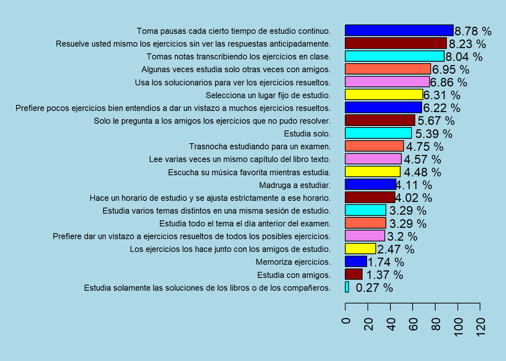

En la gráfica observamos:

- El de mayor porcentaje es 8.78% que corresponde al hábito de tomar pausas cada cierto tiempo de estudio continuo y el que tiene el porcentaje menor es de 0.27% que corresponde al hábito de estudiar solamente las soluciones de los libros o de los compañeros.
- El 51.39% pertenece a los primeros siete hábitos, de arriba abajo, mientras que el 48.62% está repartido en los 14 hábitos restantes.

Con los resultados anteriores se diría que los hábitos más frecuentes son el de tomar pausas activas, resolver por si mismo los ejercicios y tomar notas transcribiendo los ejercicios de clase y entres lo menos frecuentes se tiene a los que memorizan ejercicios, estudian con amigos y solamente estudian las soluciones. Más adelante se verá más explícitamente si realmente tener esos hábitos de estudio influyen o no en el PAPA.

Tabla de frecuencia de la variable Aleatorio

Con lo anterior obtenemos la siguiente tabla de frecuencia:

| Valor Aleatorio | Frecuencia |
| --- | --- |
| 1 | 6 |
| 6 | 8 |
| 3 | 9 |
| 10 | 9 |
| 2 | 10 |
| 9 | 10 |
| 4 | 13 |
| 5 | 14 |
| 8 | 19 |
| 7 | 34 |

Con la información anterior se realiza la siguiente gráfica:

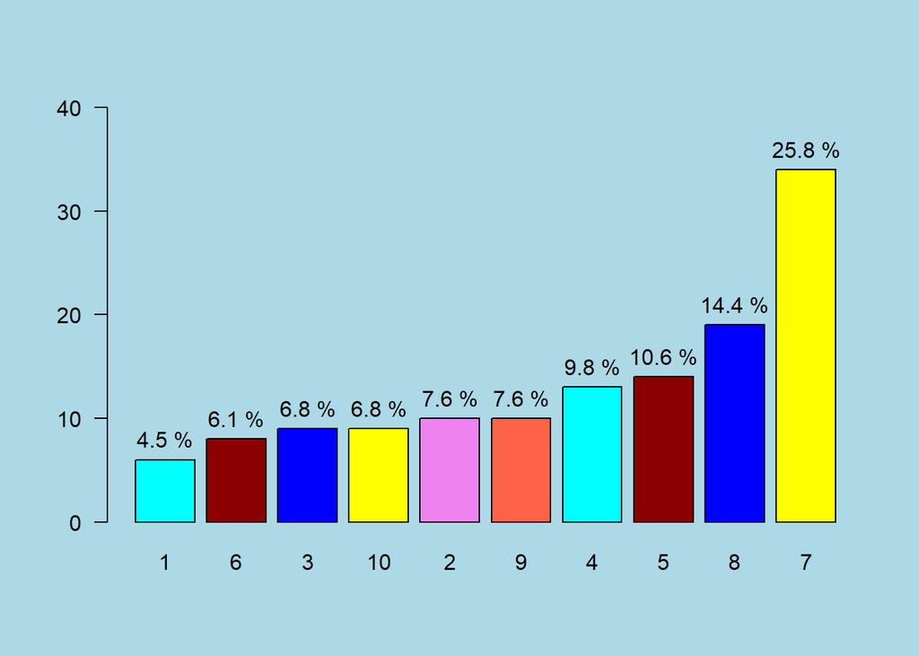

En la gráfica se observa:

- El de mayor porcentaje es del 25.8% corresponde a aquellos que eligieron el número siete y el de menor porcentaje es del 4.5% que corresponde a los que eligieron el número uno.

Con los resultados anteriores se diría que el siete (7) tiene un mayor porcentaje, para algunos el número siete representa la suerte. De igual manera tenemos que el segundo con mayor porcentaje es el número ocho (8) que para algunos tiene un significado de intuición. Es curioso que muy pocos hayan elegido el número uno (1) que tiene un significado de carácter. Si continuamos así obtenemos que para todos los números tenemos un significado curioso, quizá no sean esas las razones por las que eligieron esos números y si haya sido el primero que se les paso por la mente o de igual manera tenga un significado el número.

Comparación de la variable PAPA con la variable Género

Al relacionar la variable PAPA con la variable género, se tiene en cuenta que anteriormente se mencionó que nadie eligió la opción “otro” de la variable género. Se obtiene la siguiente gráfica:

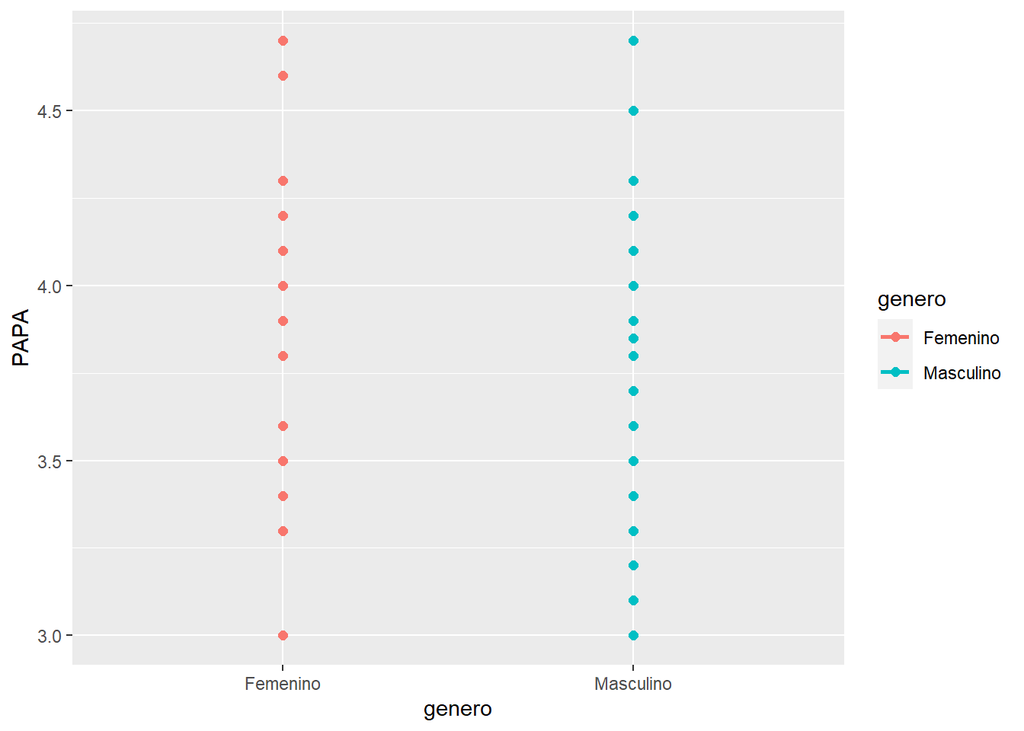

En la gráfica se observa:

- En la gráfica realizada con los datos obtenidos de la encuesta se puede notar que los hombres tienen mayor variedad de notas, por lo que se observan puntos más dispersos por la gráfica, sin embargo, para las mujeres se observa que sus notas son un poco menos dispersas, por lo que podemos ver en algunas partes hay espacios más grandes antes de llegar a otros en comparación con el de los hombres.

Con los resultados anteriores podemos decir que esas dispersiones se deben a que en el curso se entran inscritos más hombre que mujeres, teniendo en cuenta la cantidad tan desigual en los géneros que se hallan en el curso se diría que es difícil intentar hacer un tipo relación en la cual el género se pueda convertir en una posibilidad de tener un PAPA más alto o bajo.

Comparación de la variable PAPA con la variable fecha de nacimiento (Edad)

Al relacionar la variable PAPA con la edad (fecha de nacimiento) obtenemos la siguiente gráfica:

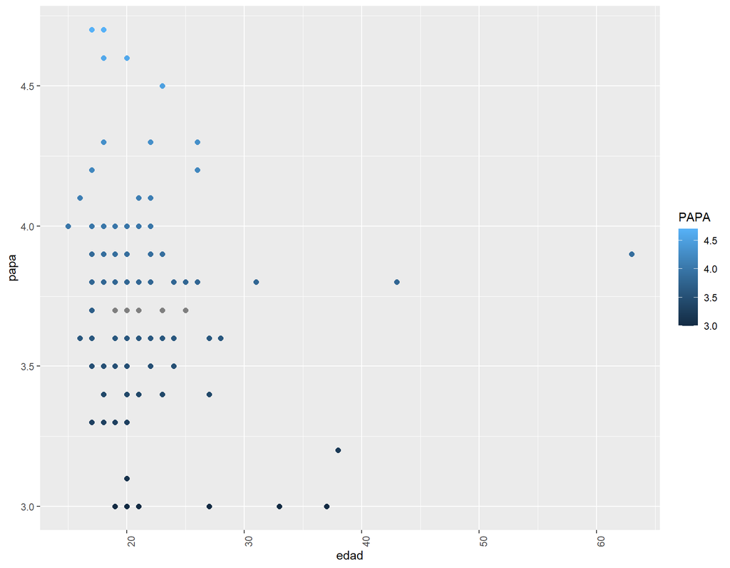

En la gráfica se observa:

- La mayor concentración de puntos se encuentra entra las edades del 15 al 30, donde varían sus calificaciones entre 3.0 a 4.0, a partir de 4.0 los resultados del PAPA son más dispersos para esas edades.
- La menor parte está en las edades del 30 al 45, con un PAPA de 3.0 a 4.0, aunque siendo los datos tan dispersos significa que son muy pocas las personas que entre esas edades tengan esas calificaciones.
- También está un dato que está en ninguna de las dos agrupaciones, es un que se encuentra entre las edades de 60 a 65, y su nota esta entre 3.8 a 4.0.

Con los resultados anteriores se podría decir que estar en cierto rango de edad no delimita las posibilidades de tener un PAPA alto o bajo, ya que, aunque la mayor concentración este en las edades de 15 a 30, también hay que ver que hay otros con edades superiores que, aunque no son mucho son suficientes para aplicar un dicho que dice “nunca es tarde para aprender”.

Comparación de la variable PAPA con la variable Carrera

En la relación de la variable PAPA con la variable carrera obtenemos la siguiente gráfica:

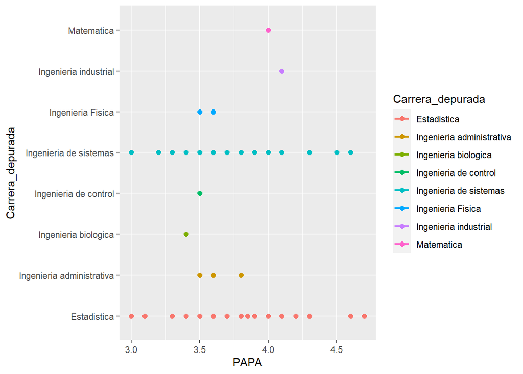

En la gráfica se observa:

- Los alumnos de ingeniería administrativa tiene notas entre 3.5 a 4.0 lo que concluye que los pocos alumnos que inscribieron la materia tienen una similitud con sus notas.
- Igualmente se puede observar que los alumnos de Estadística e Ingeniería de sistemas no tienen una similitud entre sus propias carreras ya que las notas varían entre 3.0 a 5.0.

Con los resultados obtenidos a base de la gráfica se podría decir que la carrera no tiene nada que ver en las notas del PAPA, ya que los datos varían mucho, e igual mente no se podría comparar las carreras que tienen menor porcentaje de alumnos ya que sería una población muy pequeña a comparar con poblaciones más grandes de alumnos.

Comparación de la variable PAPA con la variable Estrato

En la relación de la variable PAPA con la variable Estrato obtenemos la siguiente gráfica:

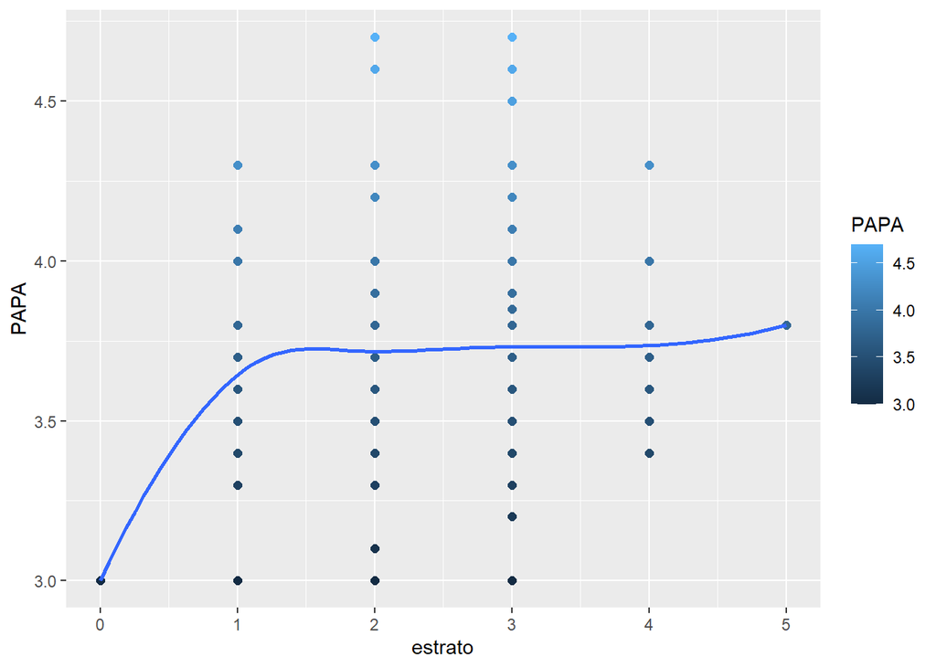

Con los resultados obtenido nos podemos dar cuenta que, en si no depende de que estrato pertenezca el alumno (aunque anteriormente se halla mencionado el alumno de estrato cero (0)), ya que podemos apreciar que entre los demás estratos también tienen alumnos con notas en 3.0 o sobre 4.0, esto demuestra que no es la zona donde venga el alumno si no las ganas de estudiar que este tenga.

Comparación de la variable PAPA con la variable Computador

Al relacionar la variable PAPA con la variable computador de mesa, refiriéndonos a la pregunta de si tiene computador de mesa, obtenemos la siguiente gráfica:

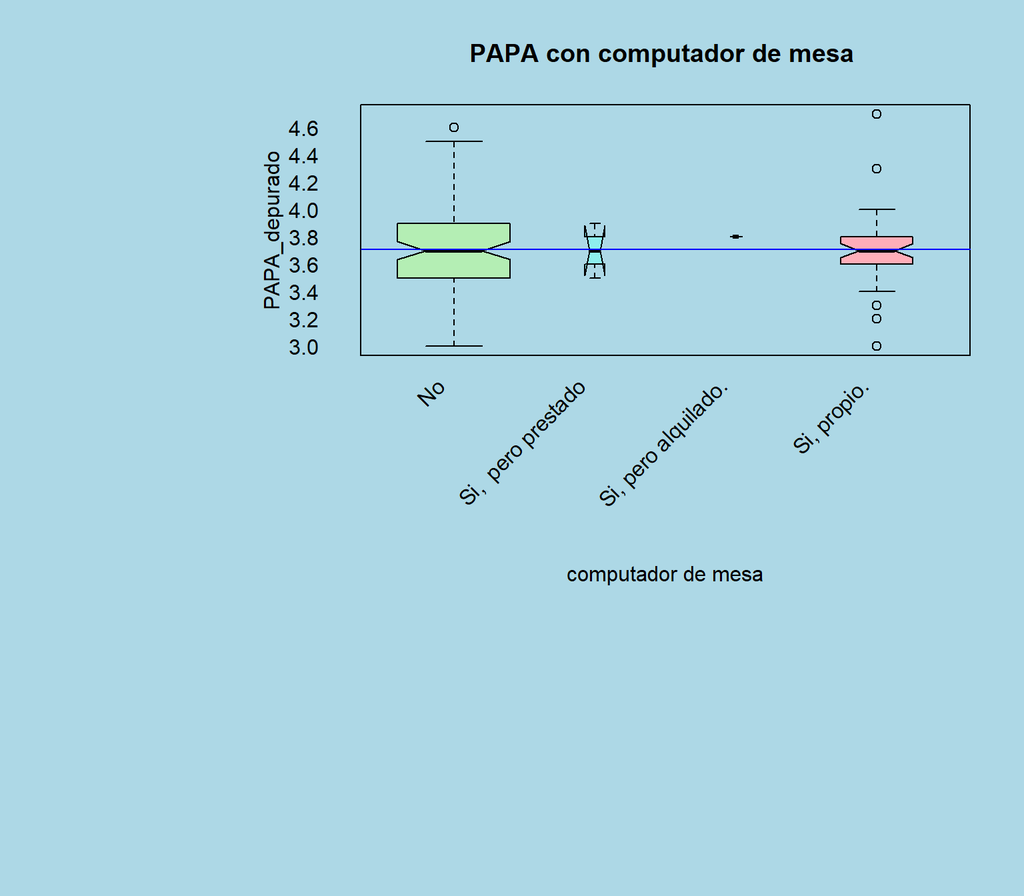

Observando la gráfica:

Con la información obtenida de la variable PAPA (mencionado con anterioridad) obtenemos que la línea central de color azul es la media con un valor del 3.7. También de la variable computador de mesa obtuvimos que se dividían en cuatro clasificaciones, de manera que al relacionar el PAPA con el computador de mesa encontramos lo siguiente: - Para la opción de respuesta “no” sus notas están entre 3.0 a 4.5, sin embargo, nos encontramos que para esa respuesta tenemos datos atípicos, es decir que a pesar de que los que respondieron que “no” estaban entre las notas de 3.0 a 4.5, hubo algunos que, aunque respondieron que “no” tienen una nota de 4.6. - En la opción de respuesta “sí, pero prestado” sus notas están entre 3.5 a 3.9, en este caso no contamos con valores atípicos, y todos los que respondieron “sí, pero prestado” están dentro de la caja de bigotes. - En la opción de respuesta “sí, pero alquilado” su nota es de 3.8, aunque si observamos bien se nota que la única persona que selecciono esa respuesta esta por encima de la media. - En la opción de respuesta “sí, propio” sus notas están entre 3.4 a 4.0 en este caso observamos que se tienen varios datos atípicos, tanto en la parte superior como en la inferior. Siendo así notamos de que a pesar de elegir la misma respuesta sus resultados son diferentes a los de la mayoría, ya que están por fuera de la caja de bigotes.

Con los resultados anteriores observamos que las medias de las cajas de bigotes coinciden con la media del PAPA, es decir que no hay mucha diferencia entre tener un computador de mesa o no, aunque también hay una caja de bigotes que esta por encima del promedio y tiene un computador de mesa alquilado.

Comparación de la variable PAPA con la variable Portatil

Al relacionar la variable PAPA con la variable portátil, refiriéndonos a la pregunta de si tiene computador portátil obtenemos la siguiente gráfica:

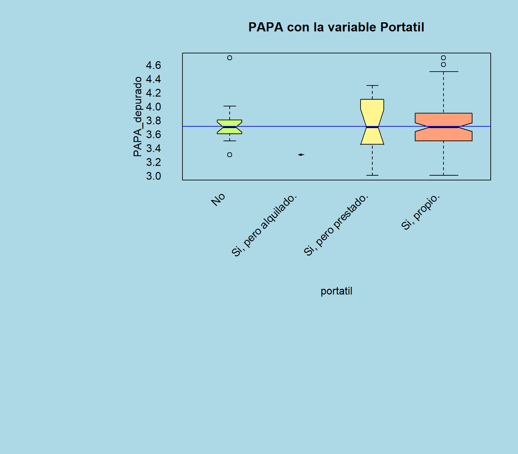

Observando la gráfica:

Con la información obtenida de la variable PAPA (mencionado con anterioridad) obtenemos que la línea central de color azul es la media con un valor del 3.7. También de la variable portátil obtuvimos que se dividían en cuatro clasificaciones, de manera que al relacionar el PAPA con la variable portátil encontramos lo siguiente:

- Para la opción de respuesta “no” sus notas están entre 3.5 a 4.0, sin embargo, nos encontramos que para esa respuesta tenemos datos atípicos, es decir que a pesar de que los que respondieron que “no” estaban entre las notas de 3.5 a 4.0, hubo algunos que, aunque respondieron que “no” tienen notas superiores e inferiores en ambos lados.
- En la opción de respuesta “sí, pero alquilado” su nota es de 3.3, si observamos bien se nota que la única persona que selecciono esa respuesta está por debajo de la media.
- En la opción de respuesta “sí, pero prestado” sus notas están entre 3.0 a 4.3, en este caso no contamos con valores atípicos, y todos los que respondieron “sí, pero prestado” están dentro de la caja de bigotes.
- En la opción de respuesta “sí, propio” sus notas están entre 3.0 a 4.4 en este caso observamos que se tienen datos atípicos, en la parte superior. Siendo así notamos de que a pesar de elegir la misma respuesta sus resultados son diferentes a los de la mayoría, ya que están por fuera de la caja de bigotes.

Con los resultados anteriores obtenemos que no hay mucha diferencia entre tener portátil o no, dado que las medias de las cajas de bigotes coinciden de forma similar con la media del PAPA, además de que no se cuentan con tantos datos atípicos. Sin embargo, tenemos que una de las cajas de bigotes está por debajo de la media del PAPA a pesar de tener portátil.

Comparación de la variable PAPA con la variable Internet

Al relacionar la variable PAPA con la variable internet, refiriéndonos a la pregunta de si tiene internet obtenemos la siguiente gráfica:

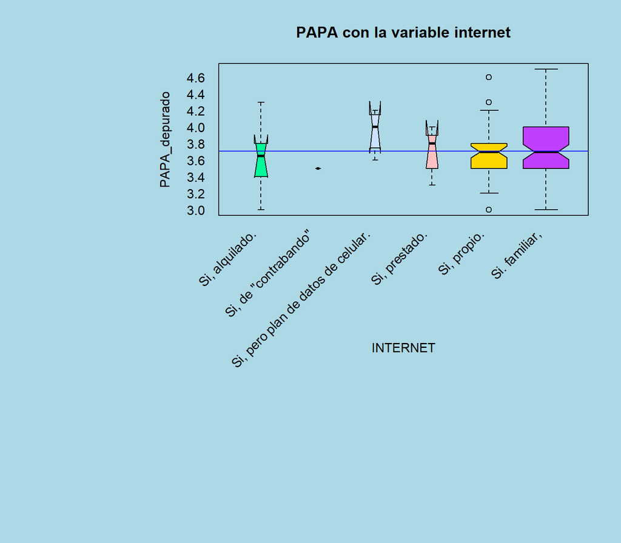

Observando la gráfica:

Con la información obtenida de la variable PAPA (mencionado con anterioridad) obtenemos que la línea central de color azul es la media con un valor del 3.7. También de la variable internet se dividía en siete clasificaciones, sin embargo, al analizar la variable internet obtuvimos que todos los encuestados tienen internet de una forma u otra, manera que la respuesta de “no” no se tendrá en cuenta. De manera que al relacionar el PAPA con la variable internet encontramos lo siguiente:

- En la opción de respuesta “sí, alquilado” tenemos que la media de la caja de bigotes se entra por debajo de la media del PAPA y además que para esta opción de respuesta no se cuenta con valores atípicos, es decir los que respondieron “sí, alquilado” tienen sus notas entre 3.0 a 4.3.
- En la opción de respuesta “sí, de “contrabando”” obtenemos la nota es de 3.5, y se encuentra por debajo de la media del PAPA.
- En la opción de respuesta “sí, pero plan de datos” la media para la respuesta se encuentra por encima de la media del PAPA, mientras que la medida del PAPA queda ubicada en el rango intercuartil (Qrange) inferior, obteniendo que sus notas están entre 3.6 a 4.2, no se cuenta con datos atípicos para este caso.
- En la opción de respuesta “sí, prestado” se tienen que la media de la caja de bigotes se encuentra por encima de la media del PAPA, sus notas están entre 3.3 a 4.0, y no se cuentan con datos atípicos.
- En la opción de respuesta “sí, propio” se tiene que la media de la caja de bigotes coincide de manera similar a la del PAPA, las notas están entre 3.2 a 4.2, y en este caso se cuenta con valores atípicos que están en la parte superior e inferior.
- En la opción de respuesta “sí, familiar” obtenemos que la media de la caja de bigotes y la media del PAPA coinciden forma similar, no se cuenta con datos atípicos y sus notas están entre 3.0 a 4.7. Con los resultados obtenidos se podría decir que los que tienen plan de datos para esta encuesta estan con una media superior a las del PAPA, aunque eso no se siempre y resulto para este caso. Tenemos que las opciones de internet familiar o propio coinciden de manera similar la mdeia del PAPA con la media de la caja de bigotes.

Comparación de la variable PAPA con la variable SmartPhone

Al relacionar la variable PAPA con la variable smarphone, refiriéndonos a la pregunta de si tiene celular inteligente obtenemos la siguiente gráfica:

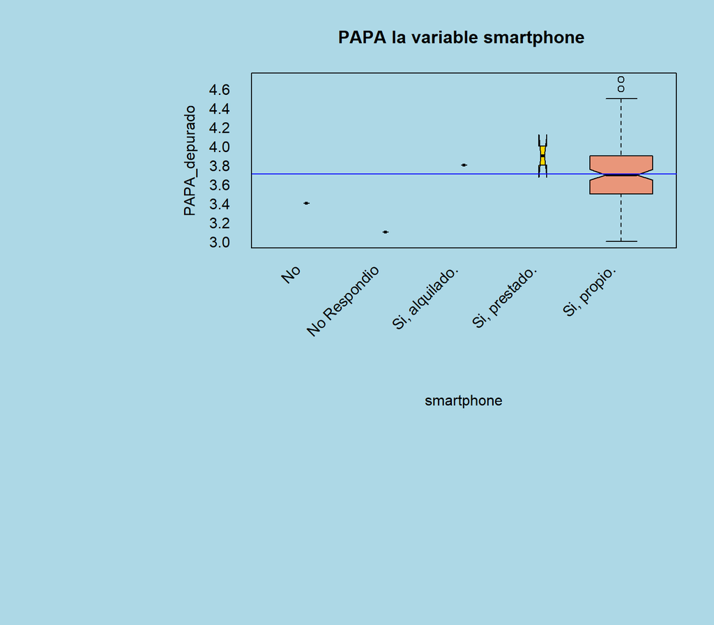

Observando la gráfica:

Con los resultados obtenidos obtenemos, que son pocos los estudiantes que a pesar de tener celular propio tiene un PAPA por encima 4.6, además de que se contaban con dos opciones que estaban por debajo del promedio y otras dos opciones que están por encima del promedio, mirándolo de esa manera y con los datos de la gráfica se podría decir que tener un celular propio puede influenciar en tener un nota alta o regular.

Comparación de la variable PAPA con la variable Estado Gov

En la relación de PAPA con estad_gov. Se obtiene la siguiente gráfica:

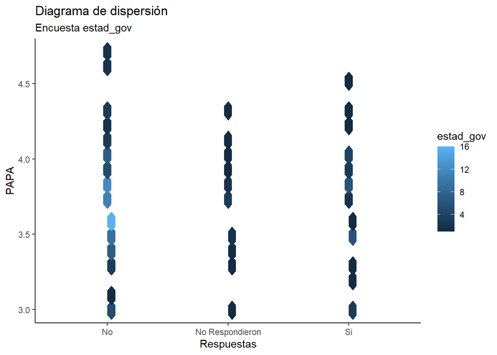

Con los resultados anteriores se diría que tener un pensamiento crítico, que no se descarta la idea de que, a pesar de opinar diferente sobre ciertos temas, como es uno tan conflictivo sobre si creer o no en las estadísticas del gobierno, independientemente de ello se podría lograr una calificación alta o regular.

Comparación de la variable PAPA con la variable origen Covid-19

Al relacionar la variable PAPA con la variable del origen del covid-19 obtenemos la siguiente gráfica:

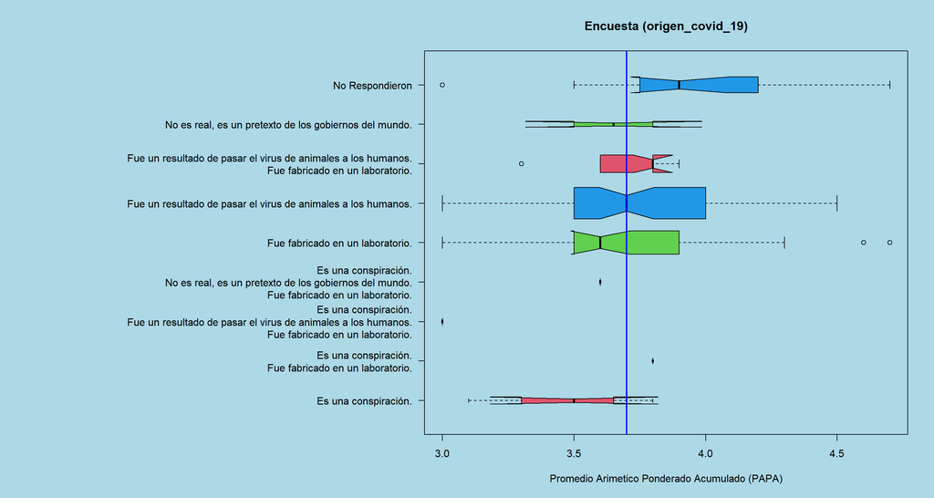

En la gráfica se observa:

- Obtenemos que seis de las cajas de bigotes no presentan ninguna anomalía, es decir, no tienen datos atípicos, y algunas se intersecan con el valor de la media del PAPA.
- Para los que no respondieron obtenemos que la media de la caja de bigotes es superior a la media del PAPA, teniendo notas entre 3.5 a 4.7. Sin embargo, nos encontramos con que tiene datos atípicos al lado izquierdo, es decir, que a pesar de haber escogido lo mismo su nota es más baja que la del resto.
- Los que eligieron dos opciones obtenemos que la media de la caja de bigote se encuentra por encima del promedio del PAPA, sin embargo, nos encontramos con dato atípico en la parte izquierda de la gráfica, donde se encuentran datos que están por fuera de la caja de bigotes y es menor al resto.
- Los que consideran que fue fabricado en un laboratorio están en con la media por debajo de la media del PAPA, sin embargo, nos encontramos con atípicos que estan con notas más altas de los que escogieron es opción.

Con los resultados anteriores se observa que puede que tener criterio más definido ayude a mantener las notas, ya que en la universidad nos enfrentamos con situaciones en las cuales debemos decidir con suma rapidez.

Comparación de la variable PAPA con la variable Habitos

Al relacionar la variable PAPA con la variable hábitos obtenemos la siguiente gráfica:

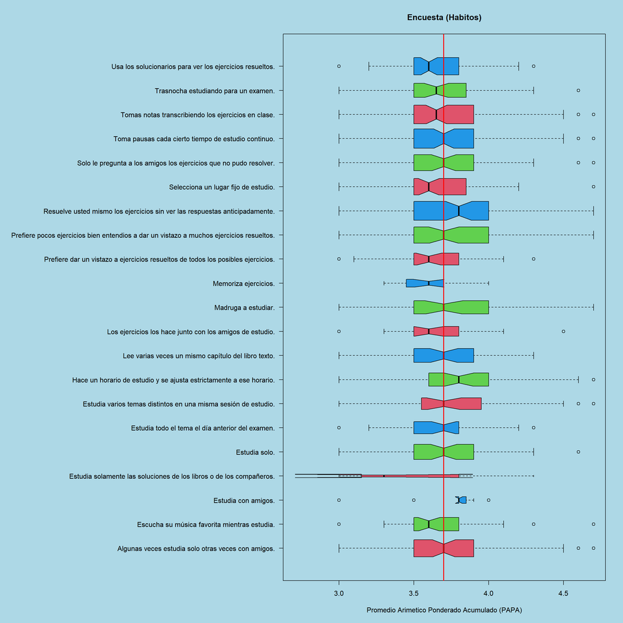

En la gráfica se observa:

- A pesar de tratarse de diferentes cajas de bigotes 20 de los hábitos intersecan con la media del PAPA, es decir se podría inferir que con cualquiera de esos hábitos se podría tener un PAPA con notas regulares o altas.
- Notamos que algunas de las cajas de bigotes poseen datos atípicos, eso quiere decir que algunas personas a pesar de tener los mismos hábitos que el resto sacaron resultados más altos o regulares que los que debían.
- Se observa que solo hay un habito que no se encuentra con la media del PAPA, sino que está un poco por encima.

Con los resultados anteriores se obtiene que, a pesar de tener hábitos de estudio diferentes, todas influyen de una u otra manera en el PAPA. Es decir, que quisa la diferencia no sea solo en los hábitos sino también en la disciplina de cada uno sobre el hábito.

Comparación de la variable PAPA con la variable Aleatorio

Al relacionar la variable PAPA con la variable aleatorio obtenemos la siguiente gráfica:

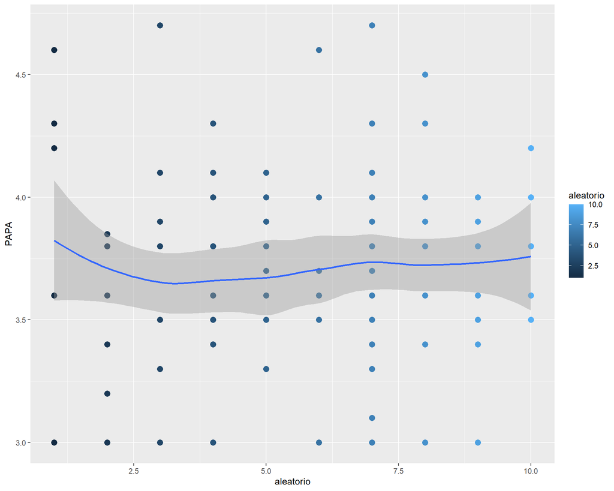

En la gráfica se observa:

Conclusión

Con los analizis obtenidos se logra decir que al parecer no todas las variables son totalmente independientes, es decir, se pueden relacionar de una u otra teniendo en cuenta cual variable depende de cual. Sumandele a ello la expericiencia de lo que es trabajar en equipo y en conjunto con personas que tienen capacidades distintas. Tambien se observo que en el momento relacionar todas las variables variables con el PAPA parecia algo que no tendria un buen resultado, sin embrago las graficas y los datos obtenidos de la encuesta que se le hizo al curso dieron a entender que algunas variables si tenian una influencia, ya sea minima, en la nota del PAPA; En su mayoría la que más tenía relevancia con la nota del PAPA eran los hábitos de estudio de cada estudiante, ya que esto nos demostró que no a todos le funcionaba el mismo hábito o que este le funcionaba a todos, este hábito podría ser bueno para el alumno o ser un hábito que perjudica sus notas.

Recomendaciones

- Se considera que para algunas de las preguntas algunas respuestas podrian sobrar.
- Seria bueno que para el siguiente trabajo tengamos una base de datos un poco más amplia, es decir, que por lo menos logren ser encuestados todos los integrantes del grupo, para asi poder realizar un más de comparaciones respecto a ciertos aspectos